# 504767967_stats102a_hw1

Lun Feng

2020/1/21

Source the R script file which is within the same folder as the R markdown file

```r
source("504767967_stats102a_hw1.R")
```

Problem 1:

gcd function: gcd<-function(x,y){

gcd function returns the greatest common divisor for two input value

argument x is a double value

argument y is a double value

Return:the function greatest common divisor which is a double value

if any of x or y is equal to zero,none-integer, or negative values {print(ERROR)}

else if(x>y){

get the reminder r by r<-x%%y

while r!=0,substitute x by y, substitute y by r, and repeat r<-x%%y untill r==0

when r==0

Then function returns value of the final y, which is the greatest common divisor of x and y }

else if(y>x){

get the reminder r by r<-y%%x

while r!=0,substitute y by x, substitute x by r, and repeat r<-y%%x untill r==0

when r==0

Then function returns value of the final x, which is the greatest common divisor of x and y

}

The flow chart of gcd function is shown

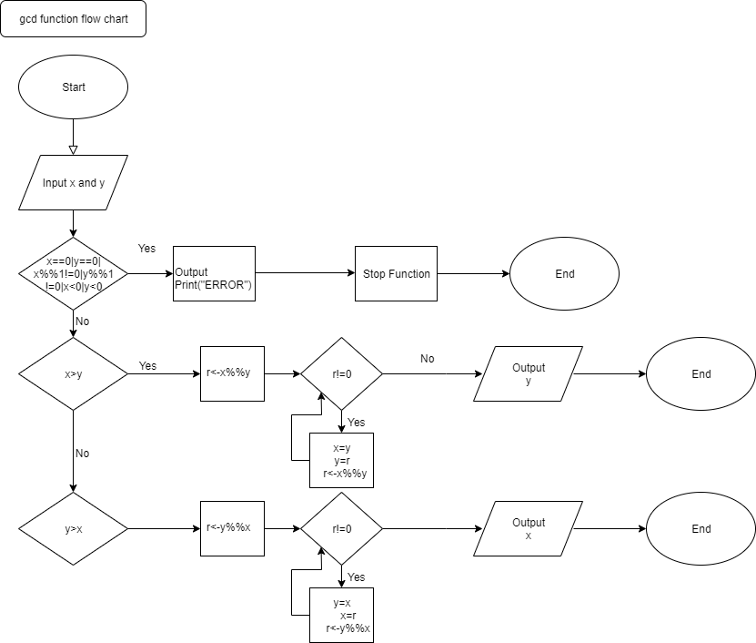

Test cases for gcd function

```r
gcd(1071, 462)
```

```
## [1] 21
```

```r
gcd(462, 1071)
```

```
## [1] 21
```

```r
gcd(646, 1406)
```

```
## [1] 38
```

```r
gcd(1, 10)
```

```
## [1] 1
```

```r
try(gcd(0, 12) )
```

```
## [1] "ERROR"
## Error in gcd(0, 12) :
```

```r
try(gcd(4.5,12))
```

```
## [1] "ERROR"
## Error in gcd(4.5, 12) :
```

```r
try(gcd(-1,12))
```

```
## [1] "ERROR"
## Error in gcd(-1, 12) :
```

gcd_three function: gcd_three<- function(a,b,c){

gcd_three function returns the greatest common divisor among 3 values

Args:

a:double, dimension is null

b:double, dimension is null

c:double, dimension is null

Return: the greatest common divisor among 3 values

use gcd(gcd(a,b),c) to get the greatest common divisor of a,b,c

*if any of a,b,c is equal to 0,non-integer,or smaller than zero{print “ERROR”} }

A detailed flowchart of gcd_three function is shown

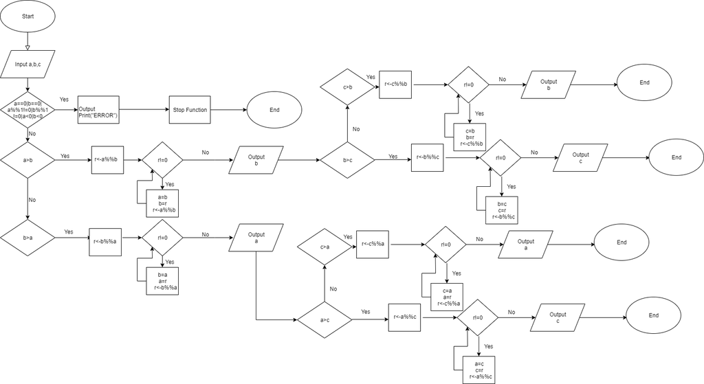

Test Cases for gcd_three

```r
      gcd_three(1071, 462, 4452)
```

```
## [1] 21
```

```r
      gcd_three(646,1406, 4218)
```

```
## [1] 38
```

Problem 2:

get_factors:

get_factors<-function(d){

get_factors return the prime factors of an input

argument d is a double value, dimension is null

Return: double values which are prime factors of input d

if d<0 or d is non-integer{ print(“ERROR”) }

else if d==1 { print(“No prime factors”) }

else if d is an even number (tested by d%%2==0){ create prime_factors which is a numeric vector and create o=3

while(d%%2==0), add 2 to prime_factors until d%%2!=0

if the remaining d==1 {return(prime_factors)}

else if the remaining d!=1{

While d!=1 {while d%%o==0 {add o to prime_factors and d<-d/o} o+2(to test the next odd number)}

eventually d would ==1, and when d==1, return(prime_factors) }}

else if d is an odd number(tested by d%%2!=0){

While d!=1 {while d%%o==0 {add o to prime_factors and d<-d/o} o+2(to test the next odd number)}

eventually d would ==1, and when d==1, return(prime_factors) }

}

The flow chart of get_factors function is shown

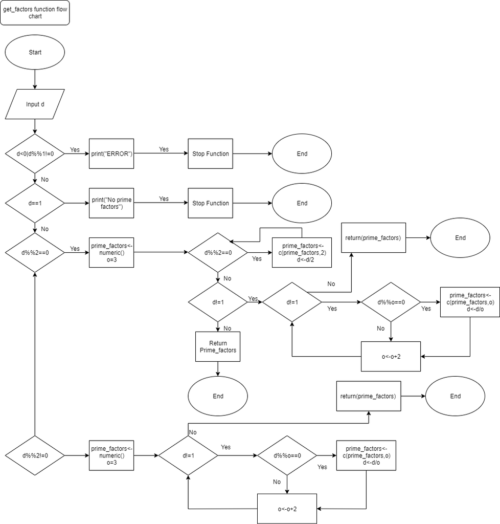

Test Cases for get_factors function

```r
get_factors(12)
```

```
## [1] 2 2 3
```

```r
get_factors(1800)
```

```
## [1] 2 2 2 3 3 5 5
```

```r
get_factors(32851)
```

```
## [1]  7 13 19 19
```

```r
get_factors(9587)
```

```
## [1] 9587
```

```r
try(get_factors(-280))
```

```
## [1] "ERROR"
## Error in get_factors(-280) :
```

```r
try(get_factors(280.75))
```

```
## [1] "ERROR"
## Error in get_factors(280.75) :
```

is_prime function: is_prime<- function(e){

is_prime function is a vectorized function that returns TRUE or FALSE depending on wheather or not value is a prime number

Argument e: double, dimenison=null

create a logical vector prime_test

assign inputlength <- length(e)

assign length of prime_test = inputlength

assign g=1

while(g<=inputlength){ if e[g]is smaller than 2, or e[g] is a non-integer{prime_test[g]=FALSE} else{ create detect_prime<-length(get_factors(e[g]))

because prime number only has one prime factor, so

when detect_prime==1,then prime_test[g]=TRUE, when detect_prime!=1,then prime_test[g]=FALSE }

g+1 }

return(prime_test)

} The flow chart of is_prime function is shown

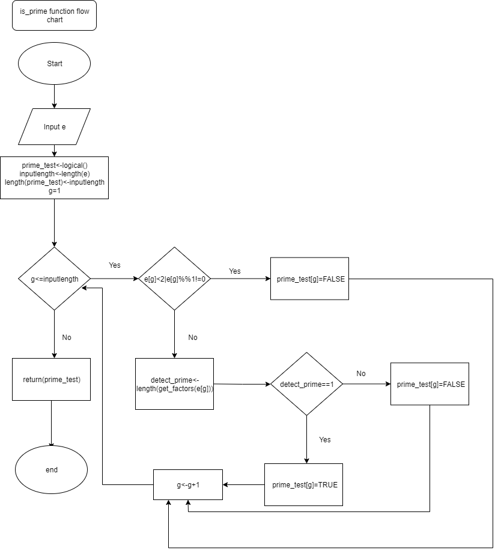

Test Case for is_prime function

```r
 is_prime(9)
```

```
## [1] FALSE
```

```r
try(is_prime(c(2,97,23,51,119, -1, 0,1.5)))
```

```
## [1]  TRUE  TRUE  TRUE FALSE FALSE FALSE FALSE FALSE
```